# Arbeitaufträge des FF auf den 24.04.2018

## Ziel der Aufgaben

Sie

- üben den Datenimport in R,
- wiederholen die Basics der einfachen Regressionsanalyse und
- wiederholen die Regressiondiagnostik zur Inferenzstatistik der einfachen Regressionsanalyse.

## Herunterladen der Daten

Für die folgenden Aufgaben brauchen Sie Daten. Aufgaben 1 & 2 beziehen sich auf die Daten des ALLBUS2016 (Vollversion): Diese können Sie [hier](https://www.gesis.org/allbus/download/download-querschnitte/) herunterladen. Dazu müssen Sie sich registrieren.

Damit Sie die Syntax der gestuften Lösungshilfen verwenden können, nennen Sie bitte das file in *ALLBUS2016.sav* um und speichern es in Ihrem Workingdirectory (also dort wo ihr RStudio-Projekt, das sie gerade verwenden auch gespeichert ist).

Auf meinem [Github-Repo zur Veranstaltung](https://github.com/sammerk/FF) finden unter der heutigen Sitzung im Ordner `data` außerdem den Fragebogen und das Codebook zum ALLBUS2016. Anhand dieser können sie die Zuordnungen $Frage \Longleftrightarrow Variablenname$ sowie $Antwort \Longleftrightarrow Variablenausprägung$ vornehmen.

## Aufgabe 1: Lebenszufriedenheit

### Aufgabenstellung

Wie stark unterscheiden sich Menschen aus den alten und neuen Bundesländern *(Variable `eastwest`)* in ihrer Lebenszufriedenheit *(Variable `ls01`)*? Suchen Sie eine Lösung mithilfe einfacher Regressionsanalyse.

### Lösungshilfe 1

Abhängige Variable: Lebenszufriedenheit  
Unabhängige Variable: alte/neue Bundesländer

### Lösungshilfe 2

`ls01` kann man als metrisch ansehen

### Lösungshilfe 3

`ls01` ist eher nicht normalverteilt.

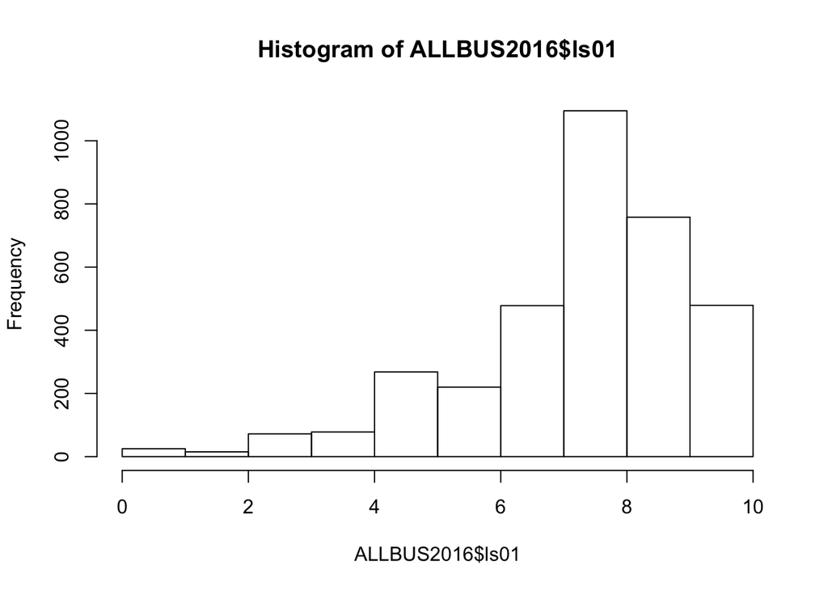

```r
library(haven) # für spss-Datei-Import
ALLBUS2016 <- read_spss("ALLBUS2016.sav")

hist(ALLBUS2016$ls01)

library(tidyverse)  # für ggplot
```

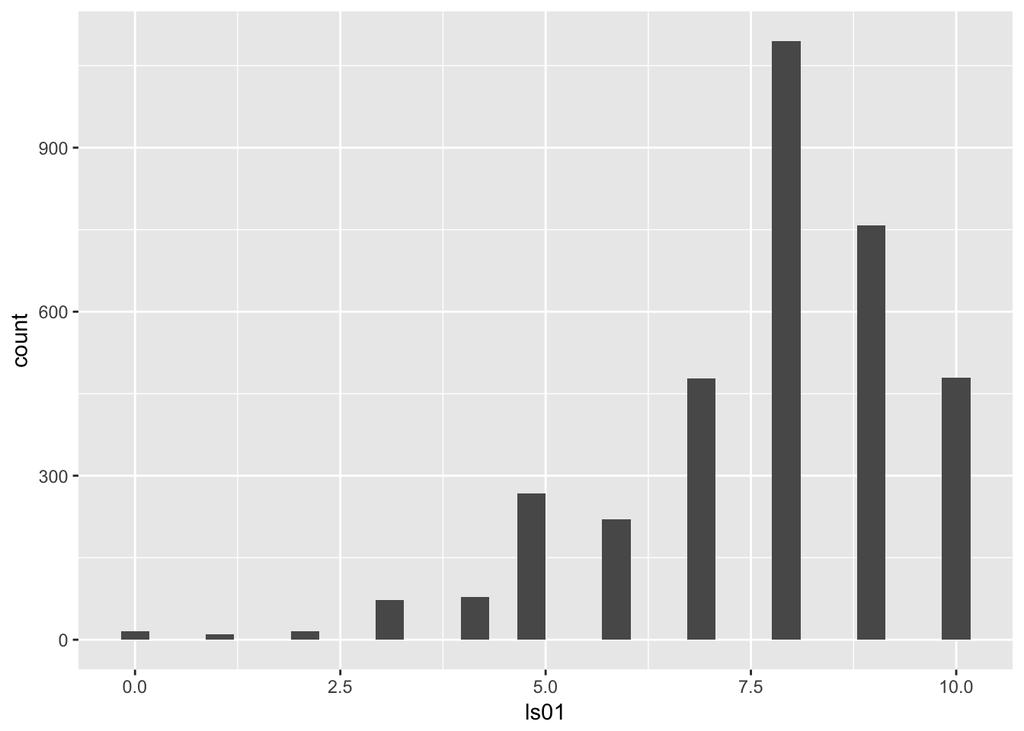

```r
ggplot(ALLBUS2016, aes(x=ls01)) + geom_histogram()
```

### Lösungshilfe 4

Also kein Cohen’s d! Möglich wären ordinale Dominanzstatistiken, das wäre aber keine Regression

```r
library(effsize) # für Vargha's A

## Da Daten in long-form sind nehmen wir effsize::VD.A,
## da diese Funktion eine Formeleingabe erlaubt.

### `as.factor()` ist notwendig, da eastwest nach dem Import
### die Klasse "Labbeled double" hat.

VD.A(ls01 ~ as.factor(eastwest), data = ALLBUS2016)
```

```
##
## Vargha and Delaney A
##
## A estimate: 0.5899116 (small)
```

```r
# Für die deskriptiven Daten
ALLBUS2016%>%
  group_by(eastwest)%>%
  summarize(meanls01 = mean(ls01, na.rm = T))
```

```
## # A tibble: 2 x 2
##   eastwest  meanls01
##   <dbl+lbl>    <dbl>
## 1 1             7.89
## 2 2             7.40
```

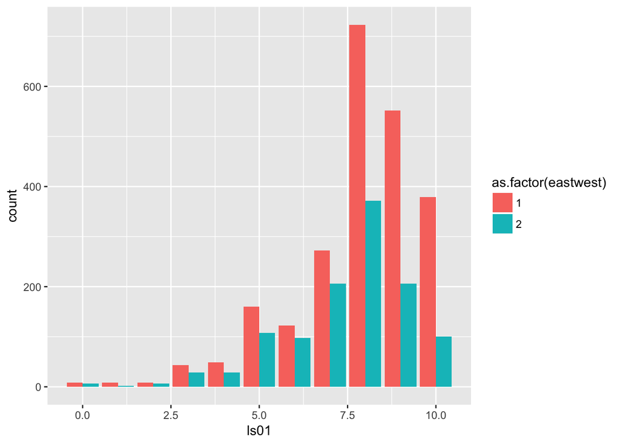

```r
# Für einen Plot
ggplot(ALLBUS2016, aes(x=ls01, fill = as.factor(eastwest))) + geom_bar(position="dodge")
```

### Lösungshilfe 5

Als Regressionsmodell

```r
reg_mod <- lm(ls01 ~ as.factor(eastwest), data = ALLBUS2016)

# für die deskriptiv Statistik:
print(reg_mod)
```

```
##
## Call:
## lm(formula = ls01 ~ as.factor(eastwest), data = ALLBUS2016)
##
## Coefficients:
##          (Intercept)  as.factor(eastwest)2
##               7.8860               -0.4813
```

```r
# für die Inferenzstatistik:
summary(reg_mod)  # Was bedeuten die p-Werte der t-Tests und des F-Tests?
```

```
##
## Call:
## lm(formula = ls01 ~ as.factor(eastwest), data = ALLBUS2016)
##
## Residuals:
## <Labelled double>
##     Min      1Q  Median      3Q     Max
## -7.8860 -0.8860  0.1140  1.1140  2.5954
##
## Labels:
##  value            label
##     -9     KEINE ANGABE
##      0 GANZ UNZUFRIEDEN
##      1               ..
##      2               ..
##      3               ..
##      4               ..
##      5               ..
##      6               ..
##      7               ..
##      8               ..
##      9               ..
##     10   GANZ ZUFRIEDEN
##
## Coefficients:
##                      Estimate Std. Error t value Pr(>|t|)
## (Intercept)           7.88597    0.03691 213.633  < 2e-16 ***
## as.factor(eastwest)2 -0.48133    0.06390  -7.533  6.3e-14 ***
## ---
## Signif. codes:  0 '***' 0.001 '**' 0.01 '*' 0.05 '.' 0.1 ' ' 1
##
## Residual standard error: 1.78 on 3486 degrees of freedom
##   (2 observations deleted due to missingness)
## Multiple R-squared:  0.01602,    Adjusted R-squared:  0.01573
## F-statistic: 56.74 on 1 and 3486 DF,  p-value: 6.299e-14
```

```r
# für schöne Tabellen:
stargazer::stargazer(reg_mod, type = "text")
```

```
##
## ================================================
##                          Dependent variable:
##                      ---------------------------
##                                 ls01
## ------------------------------------------------
## as.factor(eastwest)2          -0.481***
##                                (0.064)
##
## Constant                      7.886***
##                                (0.037)
##
## ------------------------------------------------
## Observations                    3,488
## R2                              0.016
## Adjusted R2                     0.016
## Residual Std. Error       1.780 (df = 3486)
## F Statistic           56.741*** (df = 1; 3486)
## ================================================
## Note:                *p<0.1; **p<0.05; ***p<0.01
```

## Aufgabe 2: Glücklichere Besserverdiener*innen?

### Aufgabenstellung

Wie hängen Lebenszufriedenheit *(Variable `ls01`)* und Nettoeinkommen *(Variable `di01a`)* zusammen? Untersuchen Sie anhand von Regressionmodellen und diagnostizeren Sie, inwiefern die Annahmen der Inferenzstatistik gültig sind.

### Lösungshilfe 1

Abhängige Variable: Lebenszufriedenheit  
Unabhängige Variable: Nettoeinkommen

### Lösungshilfe 2

Beide Variablen sind intervallskaliert

### Lösungshilfe 3

Die Korrelation = “einfache lineare Regression mit standardisierten Variablen” kann die Frage beantworten.

```r
## Zunächst brauchen wir einen Datensatz,
## der nur die beiden Variablen und
## keine Missings enthält ...

data_A4_narm <- ALLBUS2016%>%
  select(di01a, ls01)%>%
  na.omit(.)

summary(lm(scale(ls01) ~ scale(di01a), data = data_A4_narm))
```

```
##
## Call:
## lm(formula = scale(ls01) ~ scale(di01a), data = data_A4_narm)
##
## Residuals:
##     Min      1Q  Median      3Q     Max
## -4.3626 -0.4028  0.1813  0.6880  1.5473
##
## Coefficients:
##               Estimate Std. Error t value Pr(>|t|)
## (Intercept)  7.529e-17  1.907e-02   0.000        1
## scale(di01a) 1.894e-01  1.907e-02   9.934   <2e-16 ***
## ---
## Signif. codes:  0 '***' 0.001 '**' 0.01 '*' 0.05 '.' 0.1 ' ' 1
##
## Residual standard error: 0.9821 on 2651 degrees of freedom
## Multiple R-squared:  0.03589,    Adjusted R-squared:  0.03553
## F-statistic: 98.68 on 1 and 2651 DF,  p-value: < 2.2e-16
```

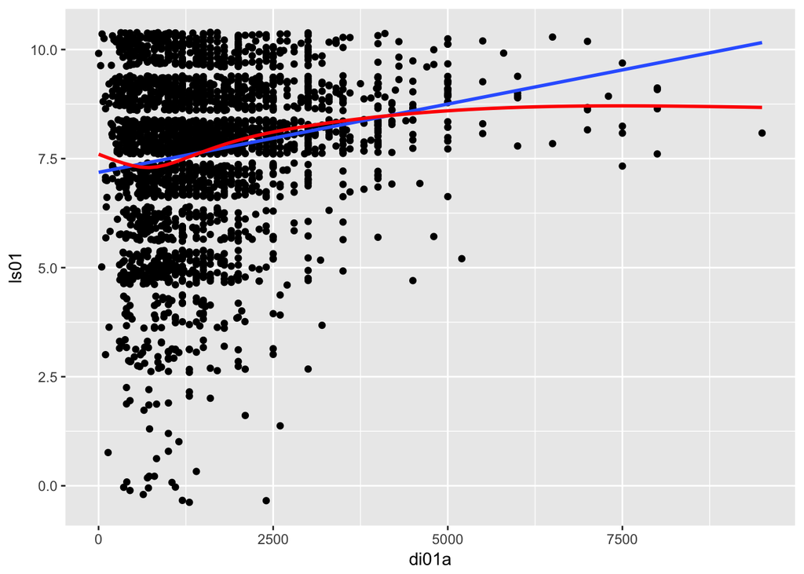

```r
## plot zur Validierung der Linearitätsannahme
ggplot(ALLBUS2016, aes(di01a, ls01)) + geom_jitter() + stat_smooth(method = "lm", se = F) + geom_smooth(color = "red", se = F)
```

### Lösungshilfe 4

Plots zur Diagnostik der Inferenzstatistik erhält man wie folgt:

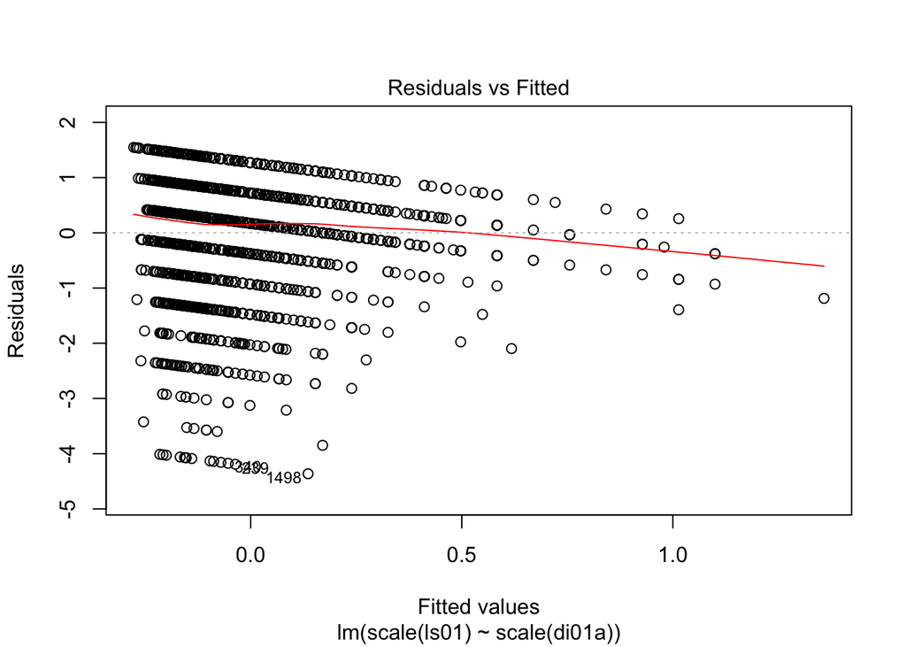

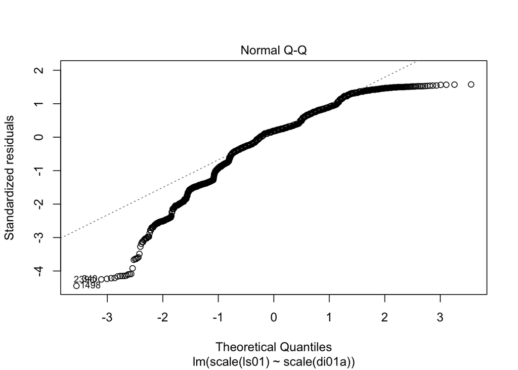

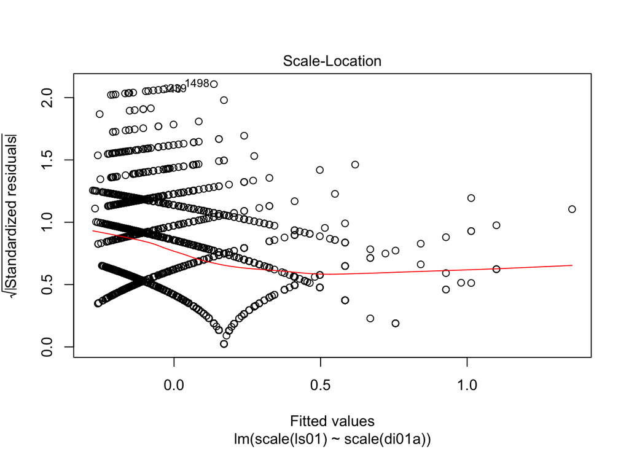

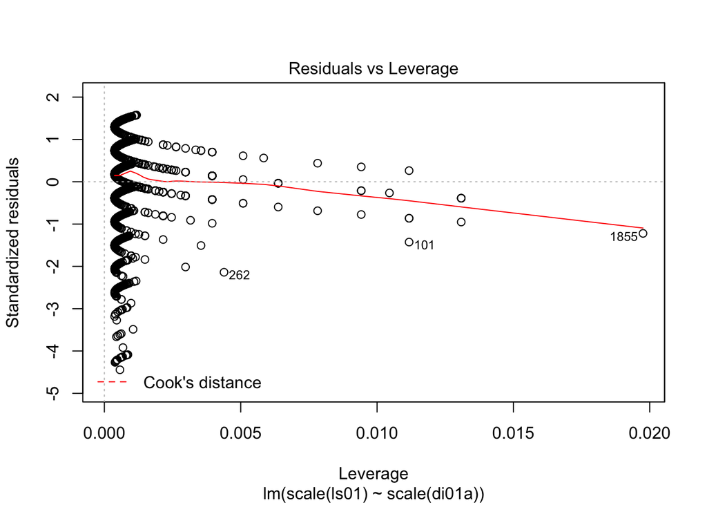

```r
## Zunächst brauchen wir einen Datensatz,
## der nur die beiden Variablen und
## keine Missings enthält ...
data_A4_narm <- ALLBUS2016%>%
  select(di01a, ls01)%>%
  na.omit(.)

# Plot der Diagnostik
plot(lm(scale(ls01) ~ scale(di01a), data = data_A4_narm))
```

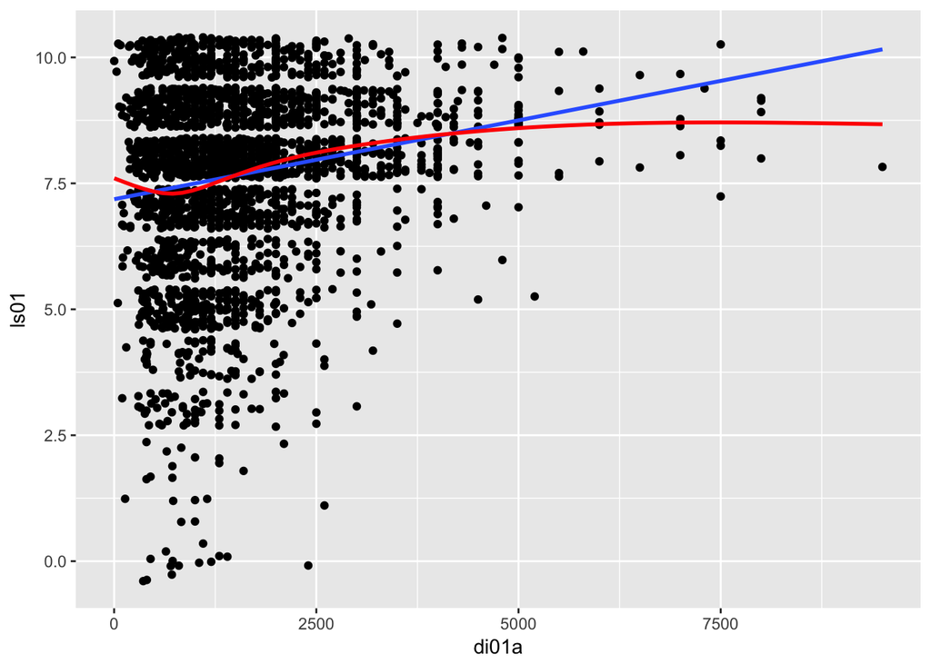

```r
# Die Verletzung der Heteroskedastizität wird auch schon im Scatterplot deutlich:
ggplot(ALLBUS2016, aes(di01a, ls01)) + geom_jitter() + stat_smooth(method = "lm", se = F) + geom_smooth(color = "red", se = F)
```

## Aufgabe 3: Verweildauern bei Unterrichtsqualitätsrückmeldungen

### Aufgabenstellung

Modellieren Sie anhand des Datensatzes `data_Informativitaet.csv` den Zusammenhang zwischen Informativität und Verweildauer mithilfe eines Regressionsmodells. Welche Annahmen sind verletzt?

### Lösungshilfe 1

Abhängige Variable: Verweildauer  
Unabhängige Variable: Informativität

### Lösungshilfe 2

Die Schätzung:

```r
# Datenimport
library(tidyverse)
data_Informativitaet <- read_delim("https://raw.githubusercontent.com/sammerk/FF/master/Sitzung_18_04_25/data/data_Informativitaet.csv",
                                   delim = ";", escape_double = FALSE, trim_ws = TRUE)
# Modellierung
reg_A3 <- lm(v_dauer_t_pp ~ Informativitaet, data = data_Informativitaet)
```

### Lösungshilfe 3

Prüfung Heteroskedastizität:

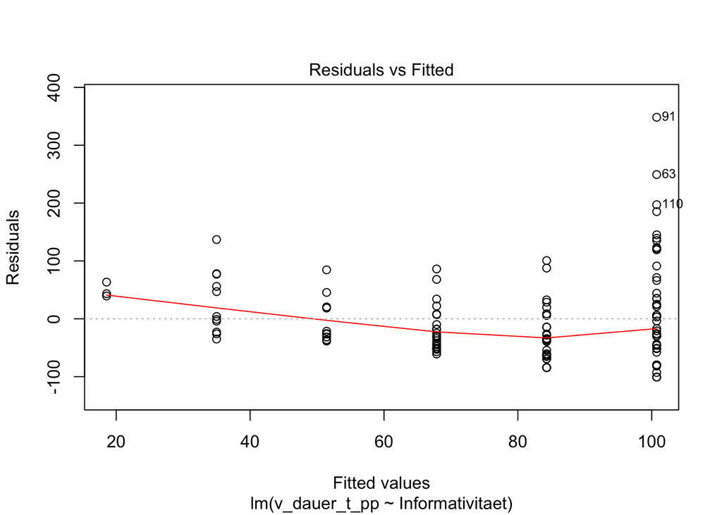

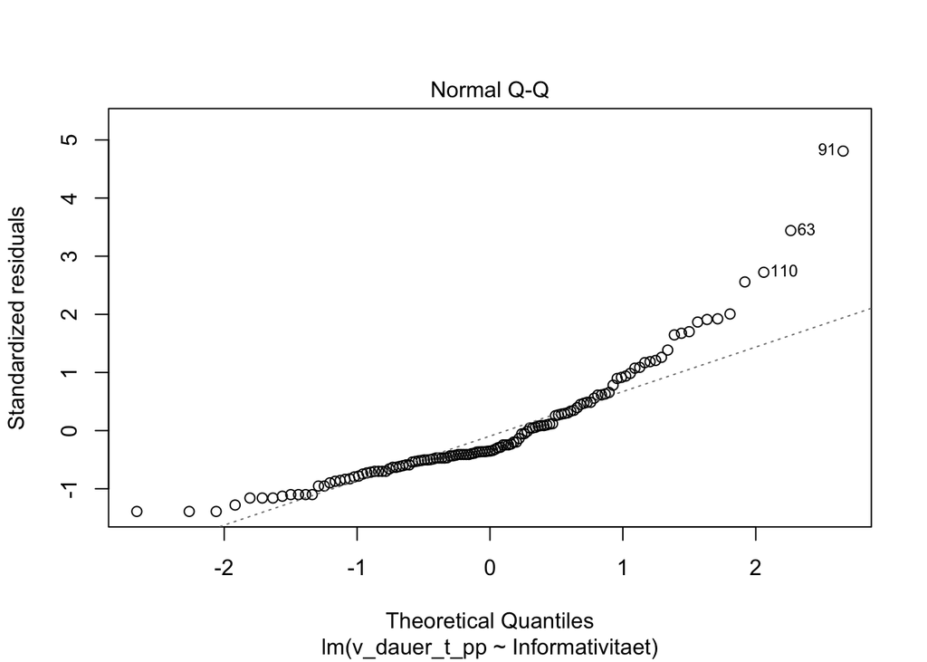

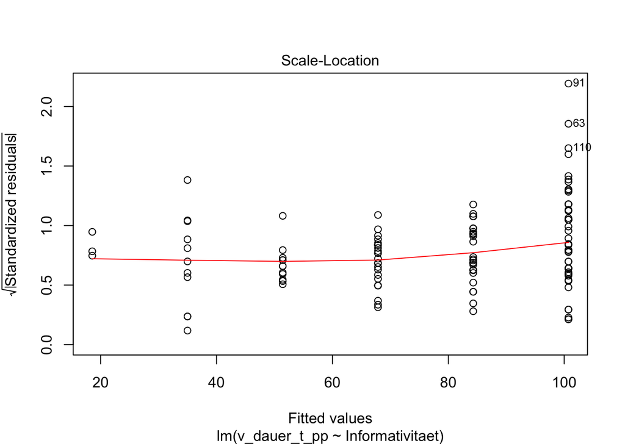

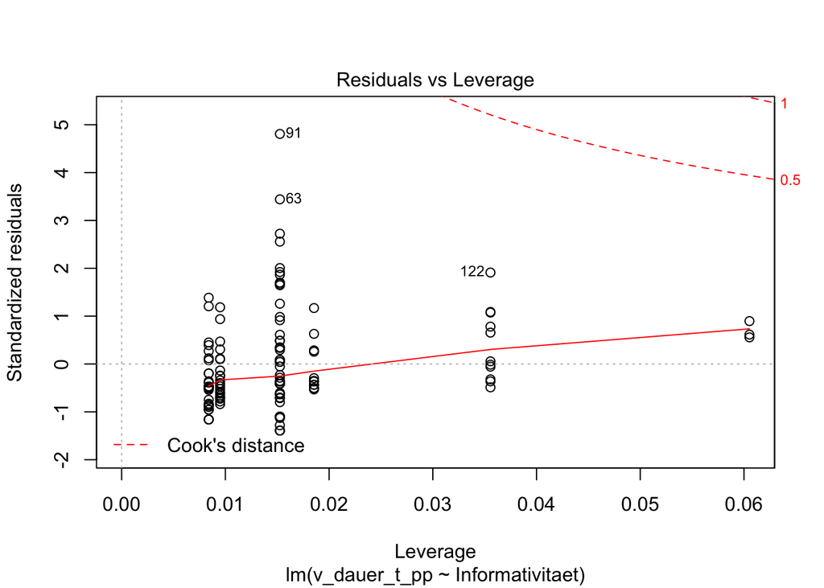

```r
plot(reg_A3)
```

Das Ergebnis ist offensichtlich problematisch!

### Lösungshilfe 4

Prüfung Linearität:

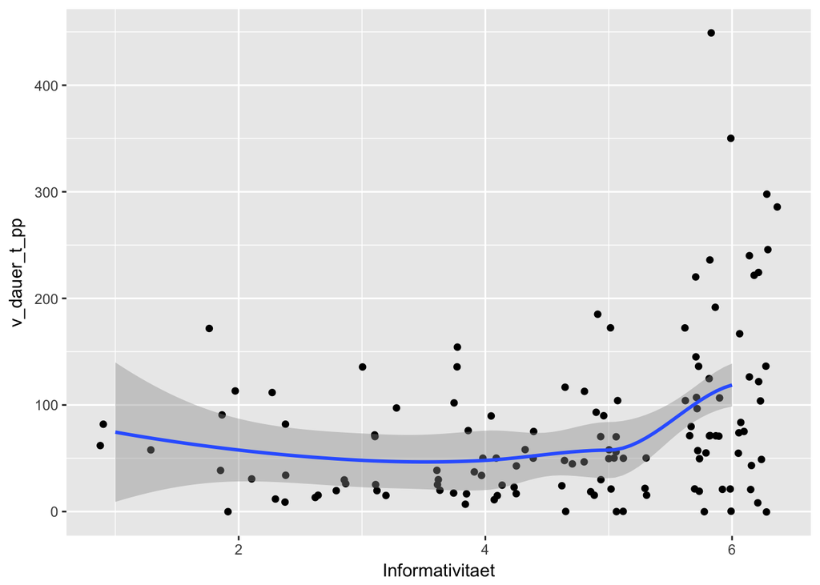

```r
ggplot(data_Informativitaet, aes(Informativitaet, v_dauer_t_pp)) + geom_jitter() + stat_smooth()
```

Das Ergebnis sieht eher nach einem U-förmigen Zusammenhang aus.

Dieses wird im nächsten Code-Chunk modelliert

```r
reg_A3_binom <- lm(v_dauer_t_pp ~ Informativitaet + I(Informativitaet^2),
                   data = data_Informativitaet)
summary(reg_A3_binom)
```

```
##
## Call:
## lm(formula = v_dauer_t_pp ~ Informativitaet + I(Informativitaet^2),
##     data = data_Informativitaet)
##
## Residuals:
##     Min      1Q  Median      3Q     Max
## -115.41  -42.66  -18.41   30.01  333.59
##
## Coefficients:
##                      Estimate Std. Error t value Pr(>|t|)
## (Intercept)           151.067     49.892   3.028  0.00300 **
## Informativitaet       -68.391     26.027  -2.628  0.00968 **
## I(Informativitaet^2)   10.408      3.147   3.307  0.00123 **
## ---
## Signif. codes:  0 '***' 0.001 '**' 0.01 '*' 0.05 '.' 0.1 ' ' 1
##
## Residual standard error: 70.25 on 124 degrees of freedom
## Multiple R-squared:  0.1661, Adjusted R-squared:  0.1526
## F-statistic: 12.35 on 2 and 124 DF,  p-value: 1.287e-05
```

```r
# Testung der inkrementellen Varianzaufklärung
anova(reg_A3, reg_A3_binom)
```

```
## Analysis of Variance Table
##
## Model 1: v_dauer_t_pp ~ Informativitaet
## Model 2: v_dauer_t_pp ~ Informativitaet + I(Informativitaet^2)
##   Res.Df    RSS Df Sum of Sq      F   Pr(>F)
## 1    125 666014
## 2    124 612021  1     53993 10.939 0.001232 **
## ---
## Signif. codes:  0 '***' 0.001 '**' 0.01 '*' 0.05 '.' 0.1 ' ' 1
```

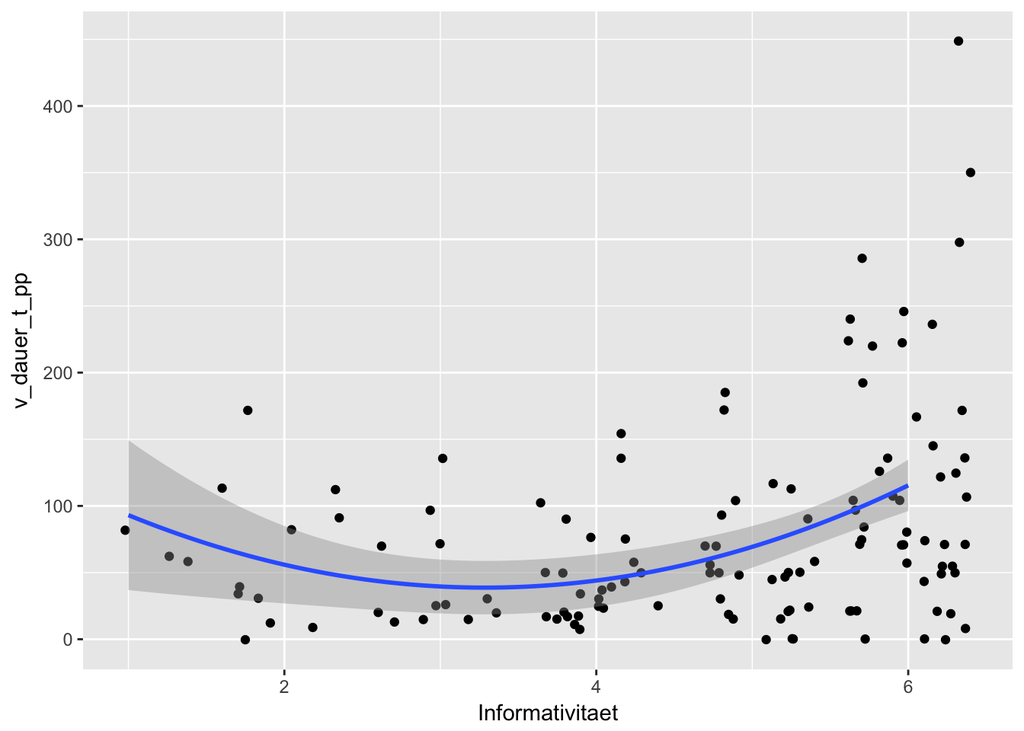

```r
# Plot des binomialen Modells
ggplot(data_Informativitaet, aes(Informativitaet, v_dauer_t_pp)) + geom_jitter() + geom_smooth(method = "lm", formula = y ~ x + I(x^2))
```

### Lösungshilfe 5

Neben den bisherigen Verletzungen der Annahmen, kommt noch hinzu, dass es schon theoretisch nicht plausibel ist, die Residuuen als i.i.d anzunehmen, da der Datensatz Messwiederholungen enthält.

Luhmann, Maike. 2013. *R für Einsteiger: Einführung in die Statistiksoftware für die Sozialwissenschaften. Mit Online-Materialien*. Beltz.